# Comparing Regularization Techniques

### Advanced Applied Machine Learning- Lab 2

### By Ciaran Lowell

This lab will compare multiple different regularization techniques on both real and simulated data. Each regressor will be run with multiple different hyperperameter settings to better compare that regressor on each dataset.

### Regressors Compared:

1. [Ridge Regression](https://scikit-learn.org/stable/modules/generated/sklearn.linear_model.Ridge.html)
2. [Lasso Regression](https://scikit-learn.org/stable/modules/generated/sklearn.linear_model.Lasso.html)
3. [Elastic Net](https://scikit-learn.org/stable/modules/generated/sklearn.linear_model.ElasticNet.html)
4. [SCAD (Smoothly Clipped Absolute Deviation)](https://hmjianggatech.github.io/picasso/pycasso.html)
5. [Square Root Lasso](https://www.statsmodels.org/stable/generated/statsmodels.regression.linear_model.OLS.fit_regularized.html)

```python
import pandas as pd
import numpy as np
import matplotlib.pyplot as plt
import keras
from keras.models import Sequential
from keras.layers import Dense
from keras.layers import Dropout
from sklearn.metrics import r2_score
from yellowbrick.regressor import ResidualsPlot
import sklearn.datasets
import sklearn
import sklearn.datasets as dt
from sklearn.model_selection import train_test_split as tts
from sklearn.linear_model import Lasso
from sklearn.preprocessing import StandardScaler

print(sklearn.__version__)
```

```
0.22.2.post1
```

```python
!pip install pycasso
```

```python
from pycasso import core
```

```python
def plotModelVariables(modeltype, model1, alpha1, model2, alpha2, model3, alpha3, data_name):
  if data_name == "Synthetic":
    XTrain, XTest, YTrain, YTest = synthXTrain, synthXTest, synthYTrain, synthYTest
    ticks = list(range(0, 6))
    xticks = synth_xticks
  elif data_name == "Diabetes":
    XTrain, XTest, YTrain, YTest = diabetesXTrain, diabetesXTest, diabetesYTrain, diabetesYTest
    ticks = list(range(0, 10))
    xticks = diabetes_xticks
  elif data_name == "Boston Housing":
    XTrain, XTest, YTrain, YTest = bostonXTrain, bostonXTest, bostonYTrain, bostonYTest
    ticks = list(range(0, 12))
    xticks = boston_xticks
  #model1_train_score = model1.score(dataXTrain,dataYTrain)
  #model1_test_score = model1.score(dataXTest, dataYTest)
  #model2_train_score = model2.score(dataXTrain,dataYTrain)
  #model2_test_score = model2.score(dataXTest, dataYTest)
  plt.plot(model1.coef_,alpha=0.7,linestyle='none',marker='*',markersize=8,color='red',label=r'%s; parameter = %s' %(modeltype, str(alpha1)), zorder=7)
  plt.plot(model2.coef_,alpha=0.5,linestyle='none',marker='d',markersize=7,color='blue',label=r'%s; parameter = %s' %(modeltype, str(alpha2)))
  plt.plot(model3.coef_,alpha=0.5,linestyle='none',marker='o',markersize=7,color='green',label=r'%s; parameter = %s' %(modeltype, str(alpha3)))
  plt.xticks(ticks, xticks)
  plt.title("%s Regression Variable Selection for %s Dataset" %(modeltype, data_name))
  plt.xlabel('Variable Index',fontsize=16)
  plt.ylabel('Coefficient Magnitude',fontsize=16)
  plt.legend(fontsize=13,loc=1)
  plt.show()
```

```python
def fitModel(model, dataset, ModelName, best = False):
  newmodel = model
  units = ''
  if dataset == "Synthetic":
    XTrain, XTest, YTrain, YTest = synthXTrain, synthXTest, synthYTrain, synthYTest
  elif dataset == "Diabetes":
    XTrain, XTest, YTrain, YTest = diabetesXTrain, diabetesXTest, diabetesYTrain, diabetesYTest
  elif dataset == "Boston Housing":
    XTrain, XTest, YTrain, YTest = bostonXTrain, bostonXTest, bostonYTrain, bostonYTest
    units = "$"
  else:
    print("Incorrect Dataset, try again")
    return
  newmodel.fit(XTrain, YTrain)
  yhat = newmodel.predict(XTest)
  mse = sklearn.metrics.mean_squared_error(YTest, yhat)
  if dataset == "Boston Housing":
      mse = mse*1000
  model_train_score=newmodel.score(XTrain,YTrain)
  model_test_score=newmodel.score(XTest,YTest)
  print("%s R^2 Accuracy on %s dataset:" %(ModelName, dataset))
  print("Train set : %f" %(model_train_score))
  print("Test set: %f" %(model_test_score))
  print("Mean Square Error: %s %.2f" %(units, mse))
  if best == True:
    return newmodel, mse, (model_test_score)
  return newmodel
```

```python
def printImportances(model, modelName, data_name):
  if data_name == "Synthetic":
    ticks = list(range(0, 6))
    xticks = synth_xticks
  elif data_name == "Diabetes":
    ticks = list(range(0, 10))
    xticks = diabetes_xticks
  elif data_name == "Boston Housing":
    ticks = list(range(0, 12))
    xticks = boston_xticks
  importances = model.coef_
  print(importances)
  for i,v in enumerate(importances):
	  print('Feature: %0d, Score: %.5f' % (i,v))
#  plot feature importance
  plt.bar([x for x in range(len(importances))], importances)
  plt.xticks(ticks, xticks)
  plt.title("%s Regression Variable Importance for %s Dataset" %(modelName, data_name))
  plt.xlabel('Variable Index',fontsize=16)
  plt.ylabel('Coefficient Magnitude',fontsize=16)
  plt.show()
```

## Datasets

#### [Boston Housing](https://www.cs.toronto.edu/~delve/data/boston/bostonDetail.html)

The X variables for this dataset are described by the data host as -

1. CRIM - per capita crime rate by town
2. ZN - proportion of residential land zoned for lots over 25,000 sq.ft.
3. INDUS - proportion of non-retail business acres per town.
4. CHAS - Charles River dummy variable (1 if tract bounds river; 0 otherwise)
5. NOX - nitric oxides concentration (parts per 10 million)
6. RM - average number of rooms per dwelling
7. AGE - proportion of owner-occupied units built prior to 1940
8. DIS - weighted distances to five Boston employment centres
9. RAD - index of accessibility to radial highways
10. TAX - full-value property-tax rate per \$10,000
11. PTRATIO - pupil-teacher ratio by town
12. B - 1000(Bk - 0.63)^2 where Bk is the proportion of African-American residents
13. LSTAT - % of residents considered low-income or impoverished

The dataset appears to have been "censored" at $50,000, with an unusual number of datapoints recording that exact price.

```python
boston = sklearn.datasets.load_boston()
bostonY = boston['target']
bostonDF = pd.DataFrame(boston.data, columns = boston.feature_names)
#show data before scaling
bostonDF['median price'] = bostonY
bostonX = bostonDF[['CRIM', 'ZN', 'INDUS', 'CHAS', 'NOX', 'RM', 'AGE', 'DIS', 'RAD', 'PTRATIO', 'B', 'LSTAT']].values
scaler = StandardScaler()
scaler.fit_transform(bostonX)
boston_xticks = ['CRIM', 'ZN', 'INDUS', 'CHAS', 'NOX', 'RM', 'AGE', 'DIS', 'RAD', 'PTRATIO', 'B', 'LSTAT']
bostonDF.head()
```

|  | CRIM | ZN | INDUS | CHAS | NOX | RM | AGE | DIS | RAD | TAX | PTRATIO | B | LSTAT | median price |
| --- | --- | --- | --- | --- | --- | --- | --- | --- | --- | --- | --- | --- | --- | --- |
| 0 | 0.00632 | 18.0 | 2.31 | 0.0 | 0.538 | 6.575 | 65.2 | 4.0900 | 1.0 | 296.0 | 15.3 | 396.90 | 4.98 | 24.0 |
| 1 | 0.02731 | 0.0 | 7.07 | 0.0 | 0.469 | 6.421 | 78.9 | 4.9671 | 2.0 | 242.0 | 17.8 | 396.90 | 9.14 | 21.6 |
| 2 | 0.02729 | 0.0 | 7.07 | 0.0 | 0.469 | 7.185 | 61.1 | 4.9671 | 2.0 | 242.0 | 17.8 | 392.83 | 4.03 | 34.7 |
| 3 | 0.03237 | 0.0 | 2.18 | 0.0 | 0.458 | 6.998 | 45.8 | 6.0622 | 3.0 | 222.0 | 18.7 | 394.63 | 2.94 | 33.4 |
| 4 | 0.06905 | 0.0 | 2.18 | 0.0 | 0.458 | 7.147 | 54.2 | 6.0622 | 3.0 | 222.0 | 18.7 | 396.90 | 5.33 | 36.2 |

```python
bostonXTrain, bostonXTest, bostonYTrain, bostonYTest = tts(bostonX, bostonY, test_size = .2, random_state = 1693, shuffle = True)
```

#### [Diabetes](https://scikit-learn.org/stable/modules/generated/sklearn.datasets.load_diabetes.html#sklearn.datasets.load_diabetes)

The Diabetes dataset represents blood measurements taken from 442 diabetes patients. The dataset has 10 X variables. The y variable is a 'quantitative measure of disease progression.'

The X variables of this dataset represent-

1. 'age'- age in years
2. 'sex'- sex of patient
3. 'bmi'- body mass index of patient
4. 'bp'- average blood pressure of patient
5. "s1" - TC, total serum cholesterol
6. "s2" - LDL, low-density lipoproteins
7. "s3"- HDL, high-density lipoproteins
8. "s4" - TCH, total cholesterol / HDL
9. "s5" - LTG, log of serum triglycerides level
10. "s6" - GLU, blood sugar level

The data has already been standardized and centered, and will not be further pre-processed before analysis.

```python
diabetes = sklearn.datasets.load_diabetes()
diabetesY = diabetes['target']
diabetesDF = pd.DataFrame(diabetes.data, columns = diabetes.feature_names)
diabetesDF['disease progression'] = diabetesY
diabetesX = diabetesDF[['age', 'sex', 'bmi', 'bp', 's1', 's2', 's3', 's4', 's5', 's6']]
diabetes_xticks = ['age', 'sex', 'bmi', 'bp', 's1', 's2', 's3', 's4', 's5', 's6']
diabetesDF.head()
```

|  | age | sex | bmi | bp | s1 | s2 | s3 | s4 | s5 | s6 | disease progression |
| --- | --- | --- | --- | --- | --- | --- | --- | --- | --- | --- | --- |
| 0 | 0.038076 | 0.050680 | 0.061696 | 0.021872 | -0.044223 | -0.034821 | -0.043401 | -0.002592 | 0.019908 | -0.017646 | 151.0 |
| 1 | -0.001882 | -0.044642 | -0.051474 | -0.026328 | -0.008449 | -0.019163 | 0.074412 | -0.039493 | -0.068330 | -0.092204 | 75.0 |
| 2 | 0.085299 | 0.050680 | 0.044451 | -0.005671 | -0.045599 | -0.034194 | -0.032356 | -0.002592 | 0.002864 | -0.025930 | 141.0 |
| 3 | -0.089063 | -0.044642 | -0.011595 | -0.036656 | 0.012191 | 0.024991 | -0.036038 | 0.034309 | 0.022692 | -0.009362 | 206.0 |
| 4 | 0.005383 | -0.044642 | -0.036385 | 0.021872 | 0.003935 | 0.015596 | 0.008142 | -0.002592 | -0.031991 | -0.046641 | 135.0 |

```python
diabetesXTrain, diabetesXTest, diabetesYTrain, diabetesYTest = tts(diabetesX, diabetesY, test_size = .2, random_state = 1693, shuffle = True)
```

#### [Synthetic Data](https://scikit-learn.org/stable/modules/generated/sklearn.datasets.make_regression.html)

A set of sythetic data will be created using SKLearn's make_regression method. The dataset conforms to a linear pattern with added noise. There are 1000 observations and 6 X variables.

```python
synthX, synthY = dt.make_regression(n_samples = 1000, n_features = 6, noise = 10, random_state = 1693)
synth_xticks = ['x1', 'x2', 'x3', 'x4', 'x5', 'x6']
```

```python
synthXTrain, synthXTest, synthYTrain, synthYTest = tts(synthX, synthY, test_size = .2, random_state = 1693, shuffle = True)
```

## [Ridge Regression](https://scikit-learn.org/stable/modules/generated/sklearn.linear_model.Ridge.html)

Ridge Regression is a linear least squares regression that uses L2 regularization.

#### Parameter: *Alpha*

Ridge's *alpha* parameter controls the strength of the regularization- higher values correspond to a stronger regularization.

We'll demonstrate 3 different Ridge fits, utilizing *alpha* 1, 10, and 100.

```python
from sklearn.linear_model import Ridge

ridgeRegressor1 = Ridge(alpha = 1.0, fit_intercept = False)

ridgeRegressor10 = Ridge(alpha = 10.0, fit_intercept = False)

ridgeRegressor100 = Ridge(alpha = 100, fit_intercept = False)
```

### Ridge - Boston

On the Boston dataset, we can see that many variable coefficients are shrunk towards zero. The models with higher *alpha* settings shrink variable coefficients closer to 0 due to the stronger regression and higher error penalties.

# Of Rooms is the most-predictive variable and is given the highest positive coefficient by all 3 models.

Proximity to noxious industry is given a negative coefficient by most models, suggesting that this is an undesirable trait for homeowners.

The Ridge Regression with *alpha* = 1 has the lowest Mean Square Error and highest R2 on the test set, and will be compared with the other models in the conclusion of this project.

```python
Ridge1Boston, Ridge1BostonMSE, Ridge1BostonR2  = fitModel(ridgeRegressor1, 'Boston Housing', 'Ridge 1', best = True)
```

```
Ridge 1 R^2 Accuracy on Boston Housing dataset:
Train set : 0.686689
Test set: 0.758593
Mean Square Error: $ 28304.09
```

```python
Ridge10Boston = fitModel(ridgeRegressor10, 'Boston Housing', 'Ridge 10')
```

```
Ridge 10 R^2 Accuracy on Boston Housing dataset:
Train set : 0.685458
Test set: 0.750710
Mean Square Error: $ 29228.37
```

```python
Ridge100Boston = fitModel(ridgeRegressor100, 'Boston Housing', 'Ridge 100')
```

```
Ridge 100 R^2 Accuracy on Boston Housing dataset:
Train set : 0.663745
Test set: 0.693713
Mean Square Error: $ 35911.11
```

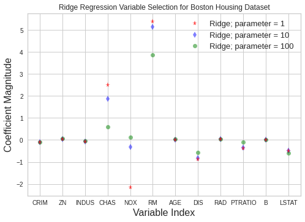

```python
plotModelVariables("Ridge", ridgeRegressor1, "1", ridgeRegressor10, '10', ridgeRegressor100, '100', "Boston Housing")
```

### Ridge - Diabetes Data

The Ridge regression appears to be poorly suited to predicting the Diabetes data. All 3 models have very poor R2 values, suggesting that a linear regression is not an appropriate fit for the Diabetes dataset.

The *alpha* = 100 regressor reduced almost all coefficients very close to 0. The messy R2 values make analysis of the other variable coefficients unreliable.

The *alpha* = 1 regressor had the lowest Mean Square Error and will be compared with the other models at the conclusion of this paper.

```python
Ridge1Diabetes, Ridge1DiabetesMSE, Ridge1DiabetesR2 = fitModel(ridgeRegressor1, 'Diabetes', 'Ridge 1', best = True)
```

```
Ridge 1 R^2 Accuracy on Diabetes dataset:
Train set : -3.338920
Test set: -4.028608
Mean Square Error:  28067.23
```

```python
Ridge10Diabetes = fitModel(ridgeRegressor10, 'Diabetes', 'Ridge 10')
```

```
Ridge 10 R^2 Accuracy on Diabetes dataset:
Train set : -3.653503
Test set: -4.039774
Mean Square Error:  28129.56
```

```python
Ridge100Diabetes = fitModel(ridgeRegressor100, 'Diabetes', 'Ridge 100')
```

```
Ridge 100 R^2 Accuracy on Diabetes dataset:
Train set : -3.824969
Test set: -4.106852
Mean Square Error:  28503.95
```

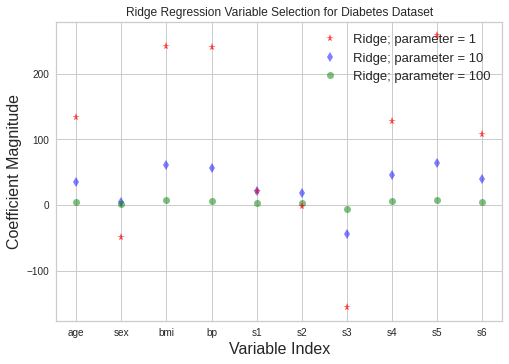

```python
plotModelVariables("Ridge", ridgeRegressor1, "1", ridgeRegressor10, '10', ridgeRegressor100, '100', "Diabetes")
```

### Ridge - Synthetic Data

All three of the Ridge models fit well to the Synthetic data, which makes sense because the synthetic data was created to be a linear distribution.

Ridge with *alpha* = 10 had the highest R2 on the test set and lowest MSE, and will be compared to the other models in the conclusion of this project.

```python
Ridge1Synthetic = fitModel(ridgeRegressor1, 'Synthetic', 'Ridge 1')
```

```
Ridge 1 R^2 Accuracy on Synthetic dataset:
Train set : 0.993079
Test set: 0.991399
Mean Square Error:  107.39
```

```python
Ridge10Synthetic, Ridge10SyntheticMSE, Ridge10SyntheticR2 = fitModel(ridgeRegressor10, "Synthetic", 'Ridge10', best = True)
```

```
Ridge10 R^2 Accuracy on Synthetic dataset:
Train set : 0.992946
Test set: 0.991423
Mean Square Error:  107.09
```

```python
Ridge100Synthetic = fitModel(ridgeRegressor100, 'Synthetic', 'Ridge 100')
```

```
Ridge 100 R^2 Accuracy on Synthetic dataset:
Train set : 0.982063
Test set: 0.981763
Mean Square Error:  227.70
```

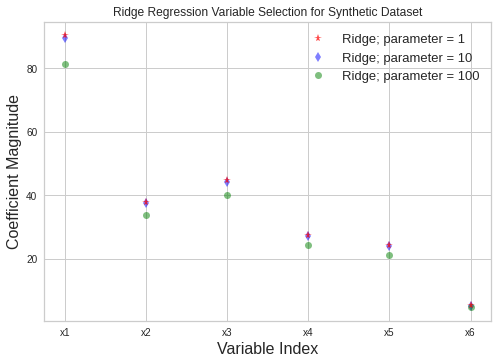

```python
plotModelVariables("Ridge", ridgeRegressor1, "1", ridgeRegressor10, '10', ridgeRegressor100, '100', "Synthetic")
```

## [Lasso Regression](https://scikit-learn.org/stable/modules/generated/sklearn.linear_model.Lasso.html)

Lasso, an acronym for Least Absolute Shrinkage and Selection Operator, is a linear regression method that uses the L1 regularization technique.

L1 regularization will force some variable coefficient weights to zero, eliminating them from use in predictions.

#### Parameter: *Alpha*

Lasso's *alpha* parameter controls the strength of the L1 regularization.

I demonstrate Lasso regressions using *alpha* values of 1, 10, and 100.

```python
lasso1 = Lasso(alpha = 1)
lasso10 = Lasso(alpha = 10)
lasso100 = Lasso(alpha = 100)
```

### Lasso - Boston Housing Data

The Lasso regressors struggle with the Boston Housing dataset. All three of them have high Mean Square Error and low R2 values.

Lasso with *alpha* = 1 has the highest R2 and lowest MSE, and will be compared to the other regressors in the conclusion.

```python
lasso1Boston, lasso1BostonMSE, lasso1BostonR2 = fitModel(lasso1, 'Boston Housing', 'Lasso 1', best = True)
```

```
Lasso 1 R^2 Accuracy on Boston Housing dataset:
Train set : 0.649853
Test set: 0.625868
Mean Square Error: $ 43865.69
```

```python
lasso10Boston = fitModel(lasso10, 'Boston Housing', 'Lasso 10')
```

```
Lasso 10 R^2 Accuracy on Boston Housing dataset:
Train set : 0.526084
Test set: 0.483965
Mean Square Error: $ 60503.38
```

```python
lasso100Boston = fitModel(lasso100, 'Boston Housing', 'Lasso 100')
```

```
Lasso 100 R^2 Accuracy on Boston Housing dataset:
Train set : 0.100410
Test set: 0.067741
Mean Square Error: $ 109304.16
```

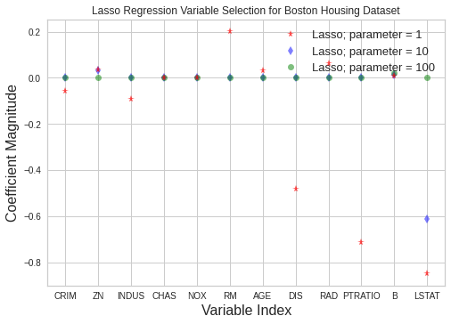

```python
plotModelVariables("Lasso", lasso1, "1", lasso10, '10', lasso100, '100', "Boston Housing")
```

### Lasso - Diabetes Data

Lasso regression struggles with the Diabetes dataset as well. Both the *alpha* = 10 and 100 regressors set all variables to zero, showing that this is too high of an *alpha* for this dataset.

```python
lasso1Diabetes, lasso1DiabetesMSE, lasso1DiabetesR2 = fitModel(lasso1, 'Diabetes', 'Lasso 1', best = True)
```

```
Lasso 1 R^2 Accuracy on Diabetes dataset:
Train set : 0.352596
Test set: 0.385384
Mean Square Error:  3430.48
```

```python
lasso10Diabetes = fitModel(lasso10, 'Diabetes', 'Lasso 10')
```

```
Lasso 10 R^2 Accuracy on Diabetes dataset:
Train set : 0.000000
Test set: -0.000068
Mean Square Error:  5581.89
```

```python
lasso100Diabetes = fitModel(lasso100, 'Diabetes', 'Lasso 100')
```

```
Lasso 100 R^2 Accuracy on Diabetes dataset:
Train set : 0.000000
Test set: -0.000068
Mean Square Error:  5581.89
```

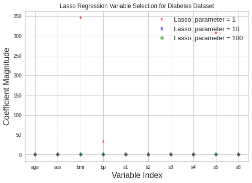

```python
plotModelVariables("Lasso", lasso1, "1",lasso10, '10', lasso100, "100", "Diabetes")
```

### Lasso - Synthetic Data

The Lasso regressors perform much better on the Synthetically generated dataset, though the *alpha* = 100 regressor still has too high of a regularization penalty and reduces all variables to 0.

The *alpha* = 1 and 10 regressors identify similar levels of importance with each variable, but the *alpha* = 10 regressor gives each variable smaller coefficients due to its higher regularization penalty.

The *alpha* = 1 regressor shows the highest R2s and lowest MSE.

```python
lasso1Synthetic, lasso1SyntheticMSE, lasso1SyntheticR2 = fitModel(lasso1, 'Synthetic', 'Lasso 1', best = True)
```

```
Lasso 1 R^2 Accuracy on Synthetic dataset:
Train set : 0.992650
Test set: 0.991439
Mean Square Error:  106.89
```

```python
lasso10Synthetic = fitModel(lasso10, 'Synthetic', 'Lasso 10')
```

```
Lasso 10 R^2 Accuracy on Synthetic dataset:
Train set : 0.954801
Test set: 0.957129
Mean Square Error:  535.27
```

```python
lasso100Synthetic = fitModel(lasso100, 'Synthetic', 'Lasso 100')
```

```
Lasso 100 R^2 Accuracy on Synthetic dataset:
Train set : 0.000000
Test set: -0.003447
Mean Square Error:  12528.71
```

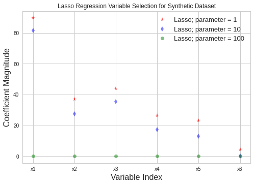

```python
plotModelVariables("Lasso", lasso1, "1", lasso10, '10', lasso100, "100", "Synthetic")
```

## [Elastic Net](https://scikit-learn.org/stable/modules/generated/sklearn.linear_model.ElasticNet.html)

Elastic Net is another method of linear regression. Where Ridge and Lasso Regressions use L2 and L1 regularizations respectively, the Elastic Net regressor uses a combination of both regularization methods.

#### *L1 Ratio* Parameter

Elastic Net's *L1 Ratio* Parameter determines how the regressor combines the L2 and L1 regularization methods. When l1_ratio = 1, the regression is equivalent to a Lasso regression. l1_ratio = 0 corresponds to a Ridge regression. Values between 0 and 1 present combine both regularization methods.

I demonstrate Elastic Net regressors using *l1_ratio* of 0.2, 0.5, and 0.8

```python
from sklearn.linear_model import ElasticNet
elastic20 = ElasticNet(alpha=1.0, l1_ratio=0.2)
elastic50 = ElasticNet(alpha = 1.0, l1_ratio = 0.5)
elastic80 = ElasticNet(alpha=1.0, l1_ratio = 0.8)
```

### Elastic Net - Boston Housing Data

The Elastic Net regressors all perform similarly well on the Boston Housing Dataset. They all identify # of Rooms as a positively correlated variable, and Lstat and PtRatio as negatively correlated variables.

The Elastic Net with L1 Ratio = 20% has the highest R2 and lowest MSE, and will be compared to other models on this dataset in the conclusion.

```python
ENet20Boston, ENet20BostonMSE, ENet20BostonR2 = fitModel(elastic20, 'Boston Housing', 'Elastic L1 = 20', best = True)
```

```
Elastic L1 = 20 R^2 Accuracy on Boston Housing dataset:
Train set : 0.669127
Test set: 0.657018
Mean Square Error: $ 40213.50
```

```python
ENet50Boston = fitModel(elastic50, 'Boston Housing', 'Elastic L1 = 50')
```

```
Elastic L1 = 50 R^2 Accuracy on Boston Housing dataset:
Train set : 0.665732
Test set: 0.651435
Mean Square Error: $ 40868.10
```

```python
ENet80Boston = fitModel(elastic80, 'Boston Housing', 'Elastic L1 = 80')
```

```
Elastic L1 = 80 R^2 Accuracy on Boston Housing dataset:
Train set : 0.659468
Test set: 0.641340
Mean Square Error: $ 42051.66
```

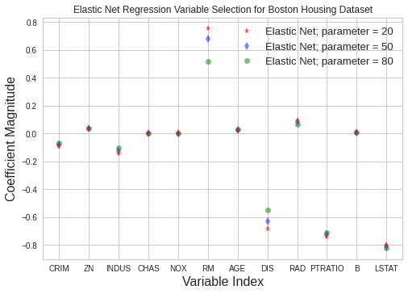

```python
plotModelVariables("Elastic Net", ENet20Boston, "20", ENet50Boston, '50', ENet80Boston, "80", "Boston Housing")
```

### Elastic Net - Diabetes Data

Like the Ridge and Lasso regressions, Elastic Net struggles with the Diabetes dataset. All three models have extremely low R2 and high MSE.

The Elastic Net regressor with L1_Ratio = 80% has the highest R2 and lowest MSE (even though both metrics are pretty poor).

```python
ENet20Diabetes = fitModel(elastic20, 'Diabetes', 'Elastic L1 = 20')
```

```
Elastic L1 = 20 R^2 Accuracy on Diabetes dataset:
Train set : 0.007010
Test set: 0.007460
Mean Square Error:  5539.87
```

```python
ENet50Diabetes = fitModel(elastic50, 'Diabetes', 'Elastic L1 = 50')
```

```
Elastic L1 = 50 R^2 Accuracy on Diabetes dataset:
Train set : 0.008717
Test set: 0.009359
Mean Square Error:  5529.27
```

```python
ENet80Diabetes, ENet80DiabetesMSE, ENet80DiabetesR2 = fitModel(elastic80, 'Diabetes', 'Elastic L1 = 80', best = True)
```

```
Elastic L1 = 80 R^2 Accuracy on Diabetes dataset:
Train set : 0.015597
Test set: 0.016926
Mean Square Error:  5487.04
```

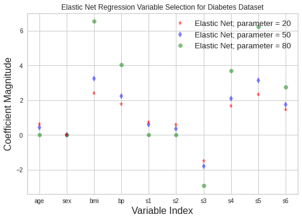

```python
plotModelVariables("Elastic Net", ENet20Diabetes, "20", ENet50Diabetes, '50', ENet80Diabetes, "80", "Diabetes")
```

### Elastic Net - Synthetic Dataset

The Elastic Net regressors perform better on the linear Synthetic data than they did on the more complicated Boston and Diabetes datasets, though they still perform worse than the Ridge and Lasso regressions.

The regressors identify X1 as the most positively correlated variable.

The Elastic Net with L1_Ratio = 80% has the best performance on this dataset.

```python
ENet20Synthetic = fitModel(elastic20, 'Synthetic', 'Elastic L1 = 20%')
```

```
Elastic L1 = 20% R^2 Accuracy on Synthetic dataset:
Train set : 0.808758
Test set: 0.810616
Mean Square Error:  2364.59
```

```python
ENet50Synthetic = fitModel(elastic50, 'Synthetic', 'Elastic L1 = 50%')
```

```
Elastic L1 = 50% R^2 Accuracy on Synthetic dataset:
Train set : 0.887908
Test set: 0.889548
Mean Square Error:  1379.06
```

```python
ENet80Synthetic, ENet80SyntheticMSE, ENet80SyntheticR2 = fitModel(elastic80, 'Synthetic', 'Elastic L1 = 80%', best = True)
```

```
Elastic L1 = 80% R^2 Accuracy on Synthetic dataset:
Train set : 0.964351
Test set: 0.964959
Mean Square Error:  437.51
```

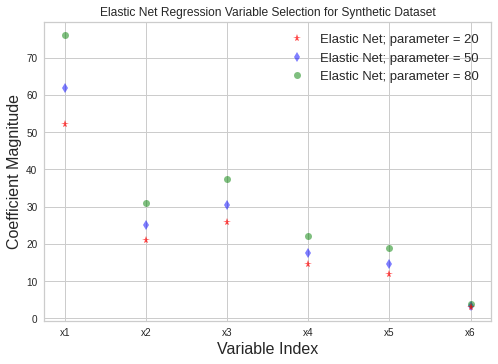

```python
plotModelVariables("Elastic Net", ENet20Synthetic, "20", ENet50Synthetic, '50', ENet80Synthetic, "80", "Synthetic")
```

## [SCAD (Smoothly Clipped Absolute Deviation)](https://fan.princeton.edu/papers/01/penlike.pdf)

The SCAD Estimator, proposed by Fan and Li in the above-linked paper, is a modification of Lasso regression. SCAD maintains Lasso's desirable qualities such as handling orthoganal cases and providing continuous solutions, but minimizes some of Lasso's problems when dealing with large regression coefficients.

I use the [Pycasso](https://hmjianggatech.github.io/picasso/pycasso.html) library's SCAD implementation. I won't show any hyperparameter options for this regressor.

### SCAD - Boston Housing Data

I don't completely understand what's happening here, but I believe this graph shows that SCAD is reducing all variables to a 0 coefficient as the regularization penalty increases.

The model has extremely low R2 and high MSE, so it is performing poorly. Its either a poor fit for the data, or I operated the tool incorrectly.

```
Training is over.
```

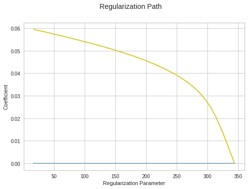

```python
scadBoston = core.Solver(bostonXTrain, bostonYTrain, family = "sqrtlasso", penalty = 'scad')
scadBoston.train()
scadBoston.plot()
```

```python
bostonyhat_scad = scadBoston.predict(bostonXTest, lambdidx= 99)
print("%s R^2 Accuracy on %s dataset:" %("SCAD", "Boston Housing"))
bostonSCADmse = sklearn.metrics.mean_squared_error(bostonYTest, bostonyhat_scad) * 1000
bostonSCADtestR2 = sklearn.metrics.r2_score(bostonYTest, bostonyhat_scad)
print("Test set: %f" %(bostonSCADtestR2))
print("Mean Square Error: %s %.2f" %("$", bostonSCADmse))
```

```
SCAD R^2 Accuracy on Boston Housing dataset:
Test set: 0.003143
Mean Square Error: $ 116878.00
```

### SCAD - Diabetes Dataset

SCAD takes a strange path selecting variables on the Diabetes dataset, and the regressor gives me errors whenever I try to evaluate the performance of the model on this dataset.

More research would be needed to debug this model and make sure it is correctly operating on this data.

```
Training is over.
```

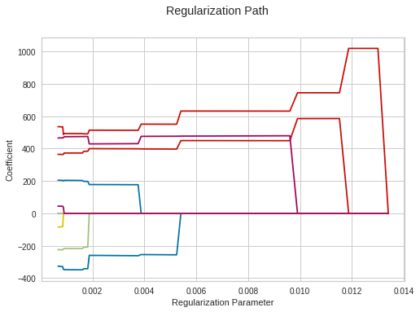

```python
scadDiabetes = core.Solver(diabetesXTrain, diabetesYTrain, family = "sqrtlasso", penalty = 'scad')
scadDiabetes.train()
scadDiabetes.plot()
```

No clue what the problem is here or why this error doesn't show up for any of the other versions of this code. Sorry.

```python
diabetesXTest.shape
```

```
(89, 10)
```

```python
diabetesyhat_scad = scadDiabetes.predict(diabetesXTestshape, lambdidx = 99)
print("%s R^2 Accuracy on %s dataset:" %("SCAD", 'diabetes'))
diabetesSCADmse = sklearn.metrics.mean_squared_error(diabetesYTest, diabetesyhat_scad) * 1000
diabetesSCADtestR2 = sklearn.metrics.r2_score(diabetesYTest, diabetesyhat_scad)
print("Test set: %f" %(diabetesSCADtestR2))
print("Mean Square Error: %s %.2f" %("$", diabetesSCADmse))
```

[output not shown]

[output cut: 10 more lines]

[output not shown]

### SCAD - Synthetic Dataset

SCAD performs well on the linear Synthetic dataset. As the regularization parameter increases, it reduces more variables to 0, eventually selecting X1 as the most important X variable in the dataset.

It performs with a high r2 value and low MSE.

```
Training is over.
```

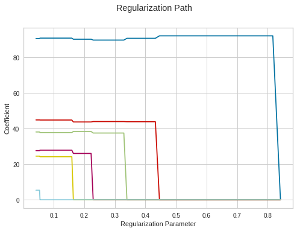

```python
scadSynthetic = core.Solver(synthXTrain, synthYTrain,family = "sqrtlasso", penalty = 'scad')
scadSynthetic.train()
scadSynthetic.plot()
```

```python
syntheticyhat_scad = scadSynthetic.predict(synthXTest, lambdidx = 99)
print("%s R^2 Accuracy on %s dataset:" %("SCAD", 'Synthetic'))
syntheticSCADmse = sklearn.metrics.mean_squared_error(synthYTest, syntheticyhat_scad)
syntheticSCADtestR2 = sklearn.metrics.r2_score(synthYTest, syntheticyhat_scad)
print("Test set: %f" %(syntheticSCADtestR2))
print("Mean Square Error: %s %.2f" %("", syntheticSCADmse))
```

```
SCAD R^2 Accuracy on Synthetic dataset:
Test set: 0.991382
Mean Square Error:  107.60
```

## [Square Root Lasso](https://www.jstor.org/stable/23076172?seq=1)

I will use the [StatsModels implementation of Square Root Lasso](https://www.statsmodels.org/devel/generated/statsmodels.regression.linear_model.OLS.fit_regularized.html) to demonstrate this regression.

I will not demonstrate any hyperparameter choices for this model.

Unfortunately, I also could not figure out how to predict values with this model. Instead, I'll just examine it's variable selection.

```python
! pip install --upgrade Cython
! pip install --upgrade git+https://github.com/statsmodels/statsmodels
import statsmodels.api as sm
```

### Square Root Lasso - Boston Housing Dataset

Square Root Lasso selects similar variables to the other models above. It chooses # of Rooms and CHAS as the most correlated X features, and assigns NOX a negative coefficient.

```python
sqrLBoston = sm.OLS(bostonYTrain,bostonXTrain)
bostonresult = sqrLBoston.fit_regularized(method='sqrt_lasso', alpha=0.5, l1_wt = 1.0)
```

```
Feature: 0, Score: -0.09428
Feature: 1, Score: 0.04247
Feature: 2, Score: -0.06469
Feature: 3, Score: 2.49946
Feature: 4, Score: -2.08656
Feature: 5, Score: 5.39102
Feature: 6, Score: 0.00019
Feature: 7, Score: -0.86776
Feature: 8, Score: 0.04230
Feature: 9, Score: -0.37381
Feature: 10, Score: 0.01619
Feature: 11, Score: -0.47415
```

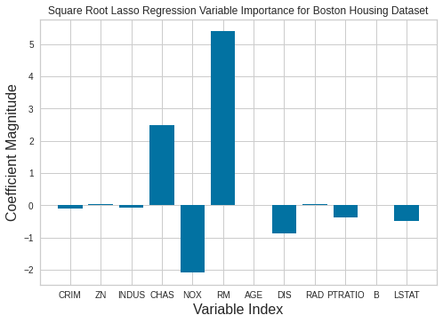

```python
importances = bostonresult.params
for i,v in enumerate(importances):
  print('Feature: %0d, Score: %.5f' % (i,v))
plt.bar([x for x in range(len(importances))], importances)
plt.xticks(list(range(0,12)), boston_xticks)
plt.title("%s Regression Variable Importance for %s Dataset" %("Square Root Lasso", "Boston Housing"))
plt.xlabel('Variable Index',fontsize=16)
plt.ylabel('Coefficient Magnitude',fontsize=16)
plt.show()
```

### Square Root Lasso - Diabetes Dataset

```python
sqrLDiabetes = sm.OLS(diabetesYTrain,diabetesXTrain)
diabetesresult = sqrLDiabetes.fit_regularized(method='sqrt_lasso', alpha=0.5)
```

[output not shown]

[figure not shown]

```python
importances = result.params
for i,v in enumerate(importances):
  print('Feature: %0d, Score: %.5f' % (i,v))
plt.bar([x for x in range(len(importances))], importances)
plt.xticks(list(range(0,10)), diabetes_xticks)
plt.title("%s Regression Variable Importance for %s Dataset" %("Square Root Lasso", "Diabetes"))
plt.xlabel('Variable Index',fontsize=16)
plt.ylabel('Coefficient Magnitude',fontsize=16)
plt.show()
```

### Square Root Lasso - Synthetic Dataset

Square Root Lasso identifies X1 as the most important variable, but also gives the other x variables positive coefficients, not reducing any to 0.

```python
sqrLSynthetic = sm.OLS(synthYTrain,synthXTrain)
syntheticresult = sqrLSynthetic.fit_regularized(method='sqrt_lasso', alpha=0.5)
```

```
Feature: 0, Score: 90.52149
Feature: 1, Score: 38.04313
Feature: 2, Score: 44.79988
Feature: 3, Score: 27.57394
Feature: 4, Score: 24.48005
Feature: 5, Score: 5.34108
```

[figure not shown]

```python
importances = result.params
for i,v in enumerate(importances):
  print('Feature: %0d, Score: %.5f' % (i,v))
plt.bar([x for x in range(len(importances))], importances)
plt.xticks(list(range(0,6)), synth_xticks)
plt.title("%s Regression Variable Importance for %s Dataset" %("Square Root Lasso", "Diabetes"))
plt.xlabel('Variable Index',fontsize=16)
plt.ylabel('Coefficient Magnitude',fontsize=16)
plt.show()
```

# Final Comparisons

Now that I've compared the regressors' hyperparameters, I'll compare the different regressors accuaracy and variable selection.

I'll create graphs comparing the regressors' importancies and error on each dataset. I'll use the version of each regressor that we had the lowest error on each dataset above.

```python
column_names = ["Model", "Mean Squared Error", "Test R2"]
model_names = ['Ridge', 'Lasso', "Elastic Net"]
```

## Boston Housing Dataset

All of the models identified that # of rooms is positively correlated with housing price. Models also identified proximity to the river as being a positive trait, while Distance from Employment Centers, Student/Teacher Ratio, and Portion of Poor Residents (LStat) were all negatively correlated with housing price.

Ridge Regression had the lowest MSE and the best R2 on the test data.

Interestingly, the Square Root Lasso variable selection mirrors the Ridge variable selection, where I expected it to mirror the Lasso selection. I'm not sure if this points to an error in implementing the regressor, or if I misunderstood how the Square Root Lasso functions.

```python
boston_mses = [Ridge1BostonMSE, lasso1BostonMSE,ENet20BostonMSE, bostonSCADmse]
boston_r2s = [Ridge1BostonR2, lasso1BostonR2, ENet20BostonR2, bostonSCADtestR2]
bostonacc = pd.DataFrame()
bostonacc["Model"] = model_names + ["SCAD"]
bostonacc["Mean Squared Error ($)"] = boston_mses
bostonacc["Test R2 "] = boston_r2s
bostonacc.round(decimals = 2)
```

|  | Model | Mean Squared Error ($) | Test R2 |
| --- | --- | --- | --- |
| 0 | Ridge | 28304.09 | 0.76 |
| 1 | Lasso | 43865.69 | 0.63 |
| 2 | Elastic Net | 40213.50 | 0.66 |
| 3 | SCAD | 116878.00 | 0.00 |

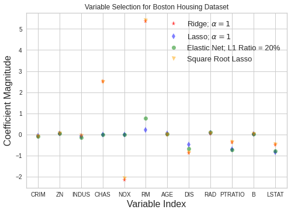

```python
ticks = list(range(0, 12))
xticks = boston_xticks
plt.plot(Ridge1Boston.coef_,alpha=0.7,linestyle='none',marker='*',markersize=8,color='red',label=r'%s; $\alpha = %s $' %("Ridge", "1"))
plt.plot(lasso1Boston.coef_,alpha=0.5,linestyle='none',marker='d',markersize=7,color='blue',label=r'%s; $\alpha = %s$' %('Lasso', "1"))
plt.plot(ENet20Boston.coef_,alpha=0.5,linestyle='none',marker='o',markersize=7,color='green',label=r'%s; L1 Ratio = %s' %("Elastic Net", '20%'))
plt.plot(bostonresult.params,alpha=0.5,linestyle='none',marker='v',markersize=7,color='orange',label=r'%s' %('Square Root Lasso'))
plt.xticks(ticks, xticks)
plt.title("Variable Selection for Boston Housing Dataset")
plt.xlabel('Variable Index',fontsize=16)
plt.ylabel('Coefficient Magnitude',fontsize=16)
plt.legend(fontsize=13,loc=1)
plt.show()
```

## Diabetes Dataset

All of the models performed very poorly on the Diabetes datasets.

Their terrible R2 values and high MSE makes me question if examining their variable selections is worthwhile.

Lasso had the highest R2 and lowest MSE.

Three out of four models selected BMI and Blood pressure as having a high correlation with disease progression. S5, one of the blood tests, was also identified as a positive correlation by Ridge, Lasso, and Square Root Lasso.

```python
diabetes_mses = [Ridge1DiabetesMSE, lasso1DiabetesMSE,ENet80DiabetesMSE]
diabetes_r2s = [Ridge1DiabetesR2, lasso1DiabetesR2, ENet80DiabetesR2]
diabetesacc = pd.DataFrame()
diabetesacc["Model"] = model_names
diabetesacc["Mean Squared Error"] = diabetes_mses
diabetesacc["Test R2 "] = diabetes_r2s
diabetesacc.round(decimals = 2)
```

|  | Model | Mean Squared Error | Test R2 |
| --- | --- | --- | --- |
| 0 | Ridge | 28067.23 | -4.03 |
| 1 | Lasso | 3430.48 | 0.39 |
| 2 | Elastic Net | 5487.04 | 0.02 |

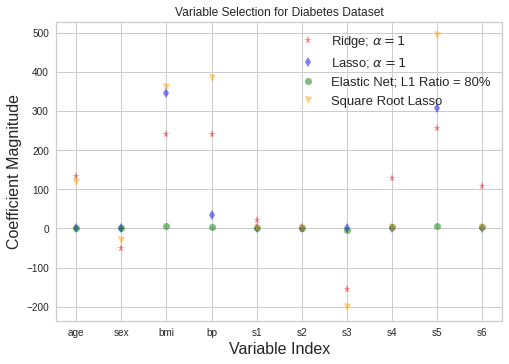

```python
ticks = list(range(0, 10))
xticks = diabetes_xticks
plt.plot(Ridge1Diabetes.coef_,alpha=0.5,linestyle='none',marker='*',markersize=8,color='red',label=r'%s; $\alpha = %s $' %("Ridge", "1"))
plt.plot(lasso1Diabetes.coef_,alpha=0.5,linestyle='none',marker='d',markersize=7,color='blue',label=r'%s; $\alpha = %s$' %('Lasso', "1"))
plt.plot(ENet80Diabetes.coef_,alpha=0.5,linestyle='none',marker='o',markersize=7,color='green',label=r'%s; L1 Ratio = %s' %("Elastic Net", '80%'))
plt.plot(diabetesresult.params,alpha=0.5,linestyle='none',marker='v',markersize=7,color='orange',label=r'%s' %('Square Root Lasso'))
plt.xticks(ticks, xticks)
plt.title("Variable Selection for Diabetes Dataset")
plt.xlabel('Variable Index',fontsize=16)
plt.ylabel('Coefficient Magnitude',fontsize=16)
plt.legend(fontsize=13,loc=1)
plt.show()
```

## Synthetic Data

The models all performed very well on the synthetic dataset, which was expected due to the data being generated with linear correlations, and most of the models tested being linear regressors.

The models all selected similar variables. X1 and X3 were the most strongly correlated variables.

```python
synth_mses = [Ridge10SyntheticMSE, lasso1SyntheticMSE,ENet80SyntheticMSE, syntheticSCADmse]
synth_r2s = [Ridge10SyntheticR2, lasso1SyntheticR2, ENet80SyntheticR2, syntheticSCADtestR2]
synthacc = pd.DataFrame()
synthacc["Model"] = model_names + ["SCAD"]
synthacc["Mean Squared Error"] = synth_mses
synthacc["Test R2 "] = synth_r2s
synthacc.round(decimals = 2)
```

|  | Model | Mean Squared Error | Test R2 |
| --- | --- | --- | --- |
| 0 | Ridge | 107.09 | 0.99 |
| 1 | Lasso | 106.89 | 0.99 |
| 2 | Elastic Net | 437.51 | 0.96 |
| 3 | SCAD | 107.60 | 0.99 |

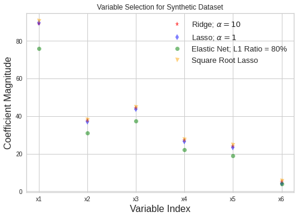

```python
ticks = list(range(0, 6))
xticks = synth_xticks
plt.plot(Ridge10Synthetic.coef_,alpha=0.7,linestyle='none',marker='*',markersize=8,color='red',label=r'%s; $\alpha = %s $' %("Ridge", "10"))
plt.plot(lasso1Synthetic.coef_,alpha=0.5,linestyle='none',marker='d',markersize=7,color='blue',label=r'%s; $\alpha = %s$' %('Lasso', "1"))
plt.plot(ENet80Synthetic.coef_,alpha=0.5,linestyle='none',marker='o',markersize=7,color='green',label=r'%s; L1 Ratio = %s' %("Elastic Net", '80%'))
plt.plot(syntheticresult.params,alpha=0.5,linestyle='none',marker='v',markersize=7,color='orange',label=r'%s' %('Square Root Lasso'))
plt.xticks(ticks, xticks)
plt.title("Variable Selection for Synthetic Dataset")
plt.xlabel('Variable Index',fontsize=16)
plt.ylabel('Coefficient Magnitude',fontsize=16)
plt.legend(fontsize=13,loc=1)
plt.show()
```